# Bayesian Modeling Problem Set 4 & 5

[figure not shown]

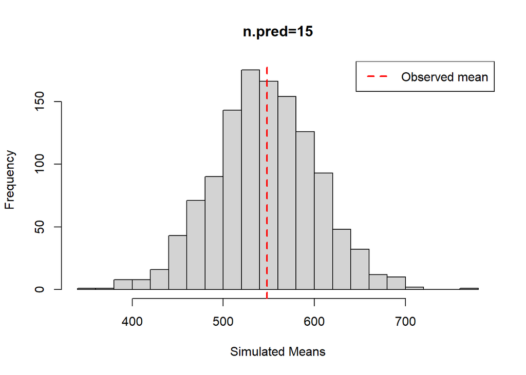

```r
ppd_mean_colony=apply(ppd_mods_15,2,mean)
ppd_mean_colony_lower_95=apply(ppd_mods_15,2,quantile,probs=0.025)
ppd_mean_colony_upper_95=apply(ppd_mods_15,2,quantile,probs=0.975)

df_15=data.frame(obs=penguin,sim_mean=ppd_mean_colony,lower=ppd_mean_colony_lower_95,upper=ppd_mean_colony_upper_95)

ggplot(df_15,aes(x=obs,y=sim_mean))+
  geom_point(col="blue",size=2)+
  geom_errorbar(aes(ymin=lower,ymax=upper), width=0.1,color="black")+
  geom_abline(intercept=0,slope=1,linetype="dashed",color="red")+
  coord_cartesian(xlim=c(0,1200),ylim=c(0,1200))+
  labs(x="Observed penguin count",y="Smulated penguin count",title ="n.pred=15")
```

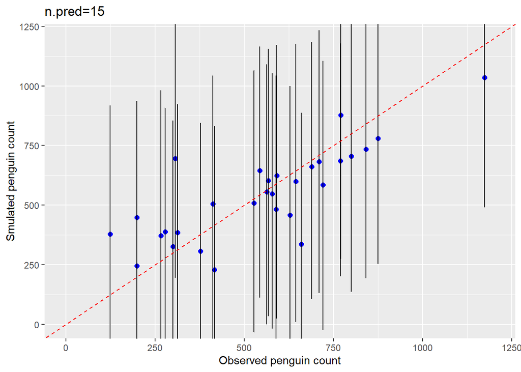

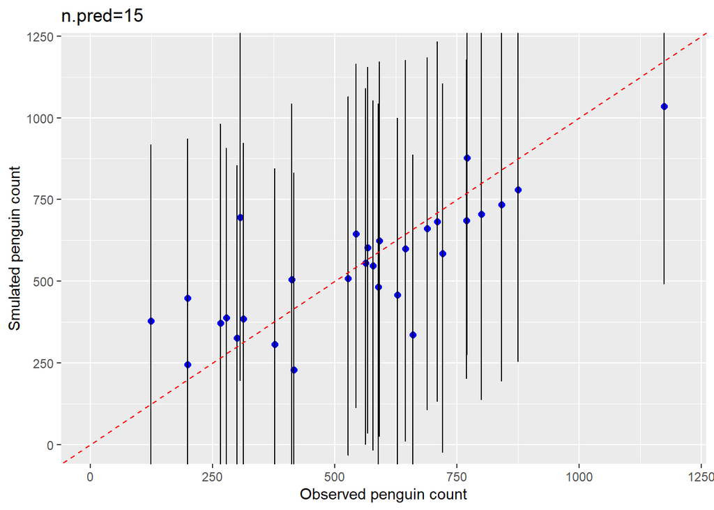

```r
#20 variables
ppd_mods_20=MCMCchains(penguin.mods[[20]],params="penguin.pred")
sim_mean_mods_20=apply(ppd_mods_20, 1, mean)
obs_mean_mods_20=mean(penguin)

hist(sim_mean_mods_20,breaks=20,main="n.pred=20",xlab="Simulated Means",ylab="Frequency")
abline(v=mean(obs_mean_mods_20),col="red",lwd=2,lty=2)
legend("topright",legend="Observed mean",col="red",lty=2,lwd=2)
```

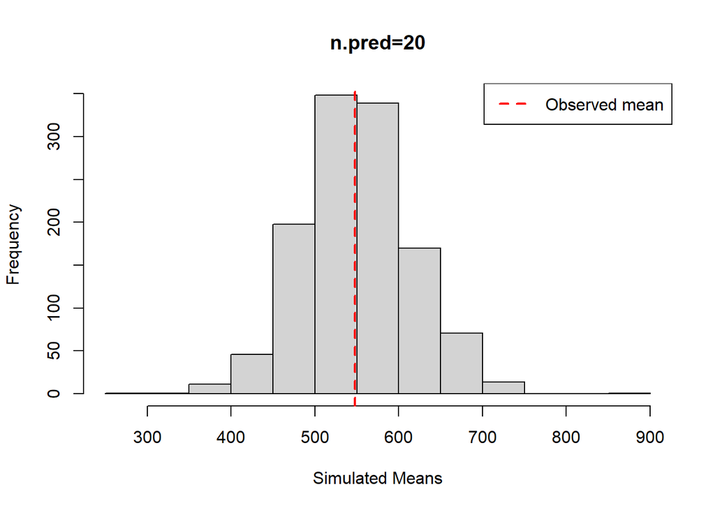

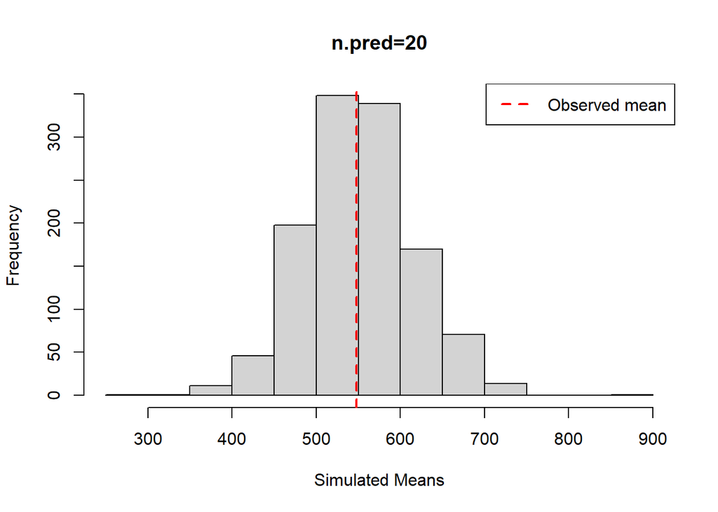

```r
ppd_mean_colony=apply(ppd_mods_20,2,mean)
ppd_mean_colony_lower_95=apply(ppd_mods_20,2,quantile,probs=0.025)
ppd_mean_colony_upper_95=apply(ppd_mods_20,2,quantile,probs=0.975)

df_20=data.frame(obs=penguin,sim_mean=ppd_mean_colony,lower=ppd_mean_colony_lower_95,upper=ppd_mean_colony_upper_95)

ggplot(df_20,aes(x=obs,y=sim_mean))+
  geom_point(col="blue",size=2)+
  geom_errorbar(aes(ymin=lower,ymax=upper),width=0.1,color="black")+
  geom_abline(intercept=0,slope=1,linetype="dashed",color="red")+
  coord_cartesian(xlim=c(0,1200),ylim=c(0,1200))+
  labs(x="Observed penguin count",y="Smulated penguin count",title ="n.pred=20")
```

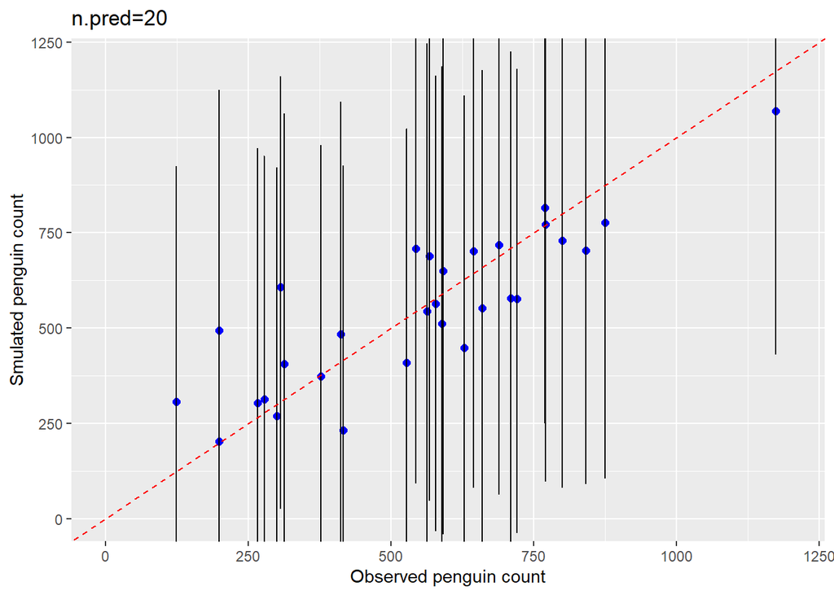

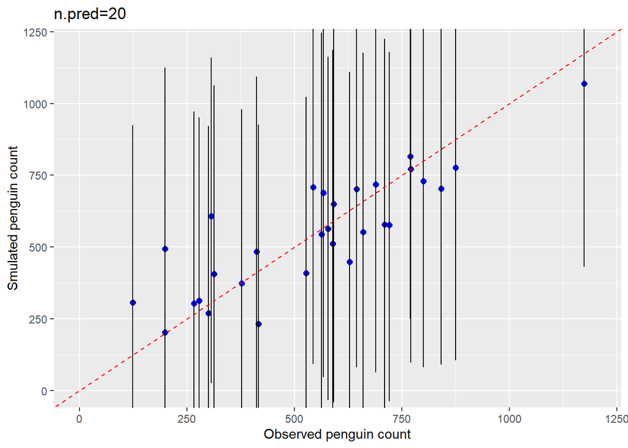

```r
#30 variables
ppd_mods_30=MCMCchains(penguin.mods[[30]],params="penguin.pred")
sim_mean_mods_30=apply(ppd_mods_30, 1, mean)
obs_mean_mods_30=mean(penguin)

hist(sim_mean_mods_30,breaks=20,main="n.pred=30",xlab="Simulated Means",ylab="Frequency")
abline(v=mean(obs_mean_mods_30),col="red",lwd=2,lty=2)
legend("topright",legend ="Observed mean",col="red",lty=2,lwd=2)
```

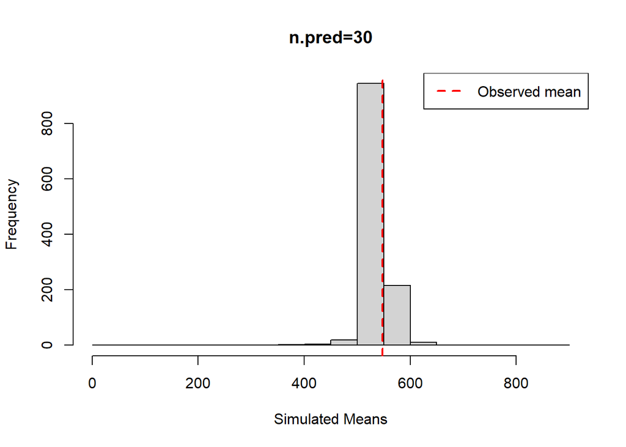

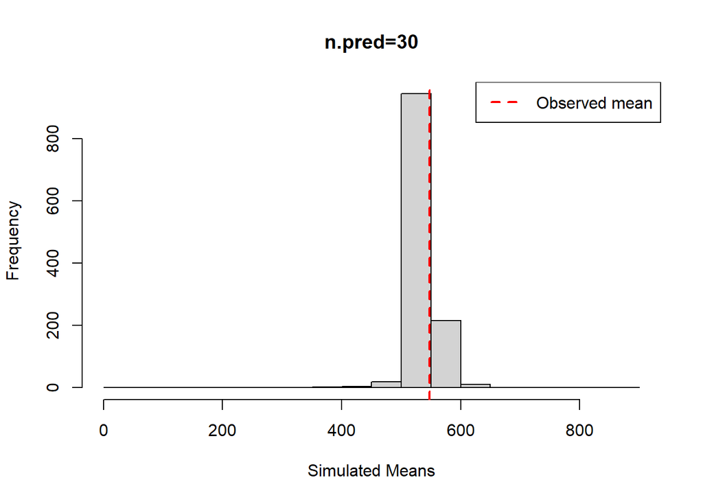

```r
ppd_mean_colony=apply(ppd_mods_30,2,mean)
ppd_mean_colony_lower_95=apply(ppd_mods_30,2,quantile,probs=0.025)
ppd_mean_colony_upper_95=apply(ppd_mods_30,2,quantile,probs=0.975)

df_30=data.frame(obs=penguin,sim_mean=ppd_mean_colony,lower=ppd_mean_colony_lower_95,upper=ppd_mean_colony_upper_95)

ggplot(df_30,aes(x=obs,y=sim_mean))+
  geom_point(col="blue",size=2)+
  geom_errorbar(aes(ymin=lower,ymax=upper),width=0.1, color="black")+
  geom_abline(intercept=0,slope=1,linetype="dashed",color="red")+
  coord_cartesian(xlim=c(0,1200),ylim=c(0,1200))+
  labs(x="Observed penguin count",y="Smulated penguin count",title ="n.pred=30")
```

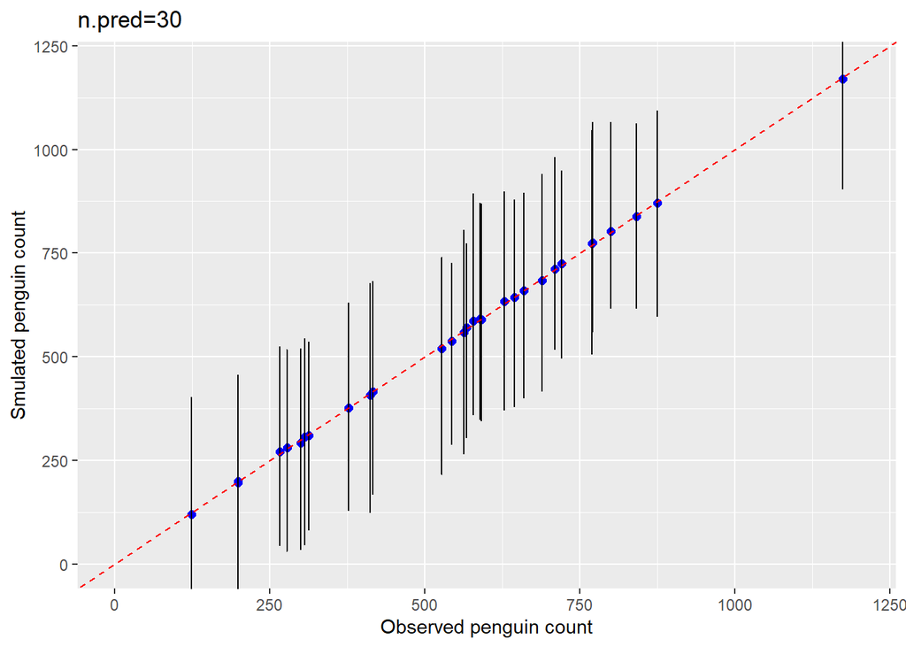

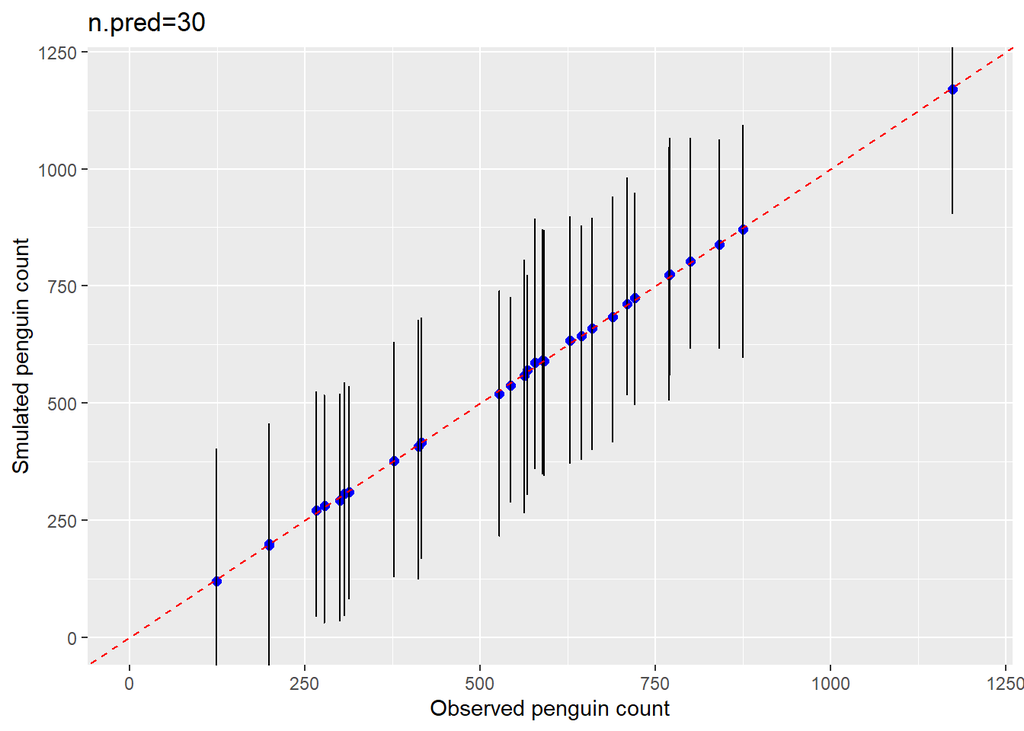